# Series Temporales

Ingeniería y Ciencia de Datos I

[Domingo López Rodríguez](https://dominlopez.netlify.app), Ángel Mora, Manuel Ojeda  
- Departamento de Matemática Aplicada, Universidad de Málaga

# 1 COVID predictions

- [P A G T A G N A: Philippine COVID-19 Case Forecasting Web Application](https://jamalrogersapp.shinyapps.io/tsforecast/)
- [Andre Calero](https://andrecalerovaldez.shinyapps.io/CovidTimeSeriesTest/)
- [covid19forecast](http://covid19forecast.science.unimelb.edu.au/?lang=es)

Note: Install **TTR**, **forecast** packages

```r
library(TTR)
library(forecast)
## Registered S3 method overwritten by 'quantmod':
##   method            from
##   as.zoo.data.frame zoo
```

# 2 Introduction

Forecasting is one of the principal applications in data science.

See [Forecasting: Principles and Practice](https://otexts.org/fpp2/)

> **Tell us what the future holds, so we may know that you are gods. (Isaiah 41:23)**

**Forecasting is the set of techniques modelling how to predict the future as accurately as possible, given all of the information available, including historical data and any future data. These methods try to extrapolate trend and seasonal patterns**

**Applications of Forecasting**

- Medicine, epidemiology,
- planning for the economy features of a country, financial institutions, pocily organizations,
- weather, global temperature changes
- scheduling in bussiness,
- marketing,
- predicting sales in a ship,
- finance and risk management,
- prediction of population in a country, in a region,
- seismic recordings
- planning th stock of product in a online shop,
- deciding whether to build another power generation plant,
- scheduling personal in a call centre depending of the number of calls,
- deciding capital investments,

See [The statistical forecasting perspective](https://otexts.org/fpp2/perspective.html)

# 3 Time series analysis

The study of adjacent points using conventional statistical methods have problems.

- Conventional statistical methods are dependent on the assumption that these adjacent observations are independent and identically distributed.
- The temporal data appears temporal correlations and ad-hoc techniques have been developed to treat these data.

**Basic steps**

- Problem study
- Data collection
- Data analysis
- Model selection and fitting
- Model validation
- Forecasting model deployment
- Monitoring forecasting model performance

# 4 Time Series in `R`

## 4.1 Importing time series

To analyse your time series data we need to read it into R, and to plot the time series.

You can read data into R using **scan()**, which assumes that your data for successive time points is in a simple text file with one column.

The file *ts_k1.dat* contains data about average business sales of a product.

```r
# Read from an URL
# Skip 1 line - comment
data.ts.k1 <- scan("ts_k1.dat", skip = 1)
head(data.ts.k1)
```

```
## [1] 60 43 67 50 56 42
```

The next step is to store the data in a time series object in R.

**A time series is a list of numbers with temporal information stored as a ts object in R**

There is a lot of packages and functions to deal with time series. Firstly, we will use **ts** function, which is used to create time-series objects.

See [ts-objects](https://otexts.org/fpp2/ts-objects.html).

```r
ts.k1 <- ts(data.ts.k1)
ts.k1
## Time Series:
## Start = 1
## End = 42
## Frequency = 1
##  [1] 60 43 67 50 56 42 50 65 68 43 65 34 47 34 49 41 13 35 53 56 16 43 69 59 48
## [26] 59 86 55 68 51 33 49 67 77 81 67 71 81 68 70 77 56
```

If the data set has values for periods less than one year, for example, monthly or quarterly, one can specify the number of times that data was collected per year by using the ‘frequency’ parameter in the **ts** function.

Dataset of unemployment in a city:

```r
tsn1 <- scan("ts_n1.dat", skip = 1)
ts.n1 <- ts(tsn1, frequency = 12, start = c(1980, 1))
ts.n1
```

```
##         Jan    Feb    Mar    Apr    May    Jun    Jul    Aug    Sep    Oct
## 1980 26.663 23.598 26.931 24.740 25.806 24.364 24.477 23.901 23.175 23.227
## 1981 21.439 21.089 23.709 21.669 21.752 20.761 23.479 23.824 23.105 23.110
## 1982 21.937 20.035 23.590 21.672 22.222 22.123 23.950 23.504 22.238 23.142
## 1983 21.548 20.000 22.424 20.615 21.761 22.874 24.104 23.748 23.262 22.907
## 1984 22.604 20.894 24.677 23.673 25.320 23.583 24.671 24.454 24.122 24.252
## 1985 23.287 23.049 25.076 24.037 24.430 24.667 26.451 25.618 25.014 25.110
## 1986 23.798 22.270 24.775 22.646 23.988 24.737 26.276 25.816 25.210 25.199
## 1987 24.364 22.644 25.565 24.062 25.431 24.635 27.009 26.606 26.268 26.462
## 1988 24.657 23.304 26.982 26.199 27.210 26.122 26.706 26.878 26.152 26.379
## 1989 24.990 24.239 26.721 23.475 24.767 26.219 28.361 28.599 27.914 27.784
## 1990 26.217 24.218 27.914 26.975 28.527 27.139 28.982 28.169 28.056 29.136
## 1991 26.589 24.848 27.543 26.896 28.878 27.390 28.065 28.141 29.048 28.484
## 1992 27.132 24.924 28.963 26.589 27.931 28.009 29.229 28.759 28.405 27.945
## 1993 26.076 25.286 27.660 25.951 26.398 25.565 28.865 30.000 29.261 29.012
##         Nov    Dec
## 1980 21.672 21.870
## 1981 21.759 22.073
## 1982 21.059 21.573
## 1983 21.519 22.025
## 1984 22.084 22.991
## 1985 22.964 23.981
## 1986 23.162 24.707
## 1987 25.246 25.180
## 1988 24.712 25.688
## 1989 25.693 26.881
## 1990 26.291 26.987
## 1991 26.634 27.735
## 1992 25.912 26.619
## 1993 26.992 27.897
```

```r
tsf1 <- scan("ts_f1.dat")
ts.f1 <- ts(tsf1, frequency = 12, start = c(1987, 1))
ts.f1
```

```
##            Jan       Feb       Mar       Apr       May       Jun       Jul
## 1987   1664.81   2397.53   2840.71   3547.29   3752.96   3714.74   4349.61
## 1988   2499.81   5198.24   7225.14   4806.03   5900.88   4951.34   6179.12
## 1989   4717.02   5702.63   9957.58   5304.78   6492.43   6630.80   7349.62
## 1990   5921.10   5814.58  12421.25   6369.77   7609.12   7224.75   8121.22
## 1991   4826.64   6470.23   9638.77   8821.17   8722.37  10209.48  11276.55
## 1992   7615.03   9849.69  14558.40  11587.33   9332.56  13082.09  16732.78
## 1993  10243.24  11266.88  21826.84  17357.33  15997.79  18601.53  26155.15
##            Aug       Sep       Oct       Nov       Dec
## 1987   3566.34   5021.82   6423.48   7600.60  19756.21
## 1988   4752.15   5496.43   5835.10  12600.08  28541.72
## 1989   8176.62   8573.17   9690.50  15151.84  34061.01
## 1990   7979.25   8093.06   8476.70  17914.66  30114.41
## 1991  12552.22  11637.39  13606.89  21822.11  45060.69
## 1992  19888.61  23933.38  25391.35  36024.80  80721.71
## 1993  28586.52  30505.41  30821.33  46634.38 104660.67
```

## 4.2 Displaying time series

Let us make a basic plot of the time series data (for the two first datasets):

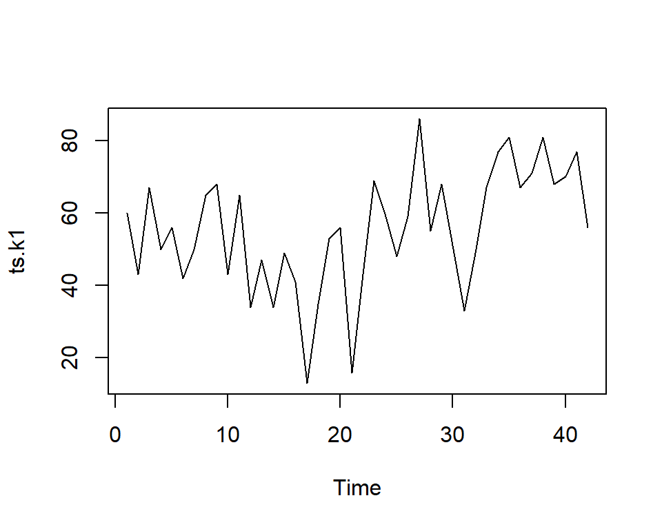

```r
plot.ts(ts.k1)
```

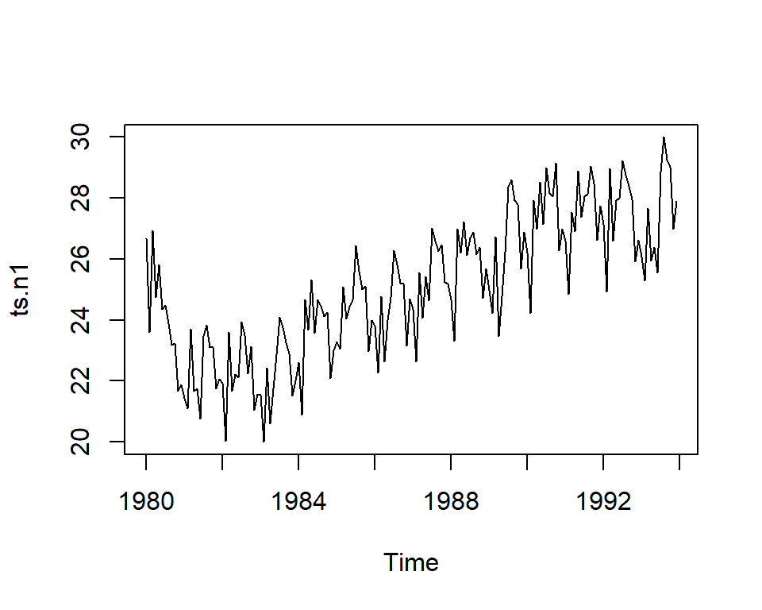

```r
plot.ts(ts.n1)
```

In the second one, there seems to be seasonal variation in the number of unemployees per month: There is a peak every summer, and a trough every winter.

The plot for the third dataset is the following:

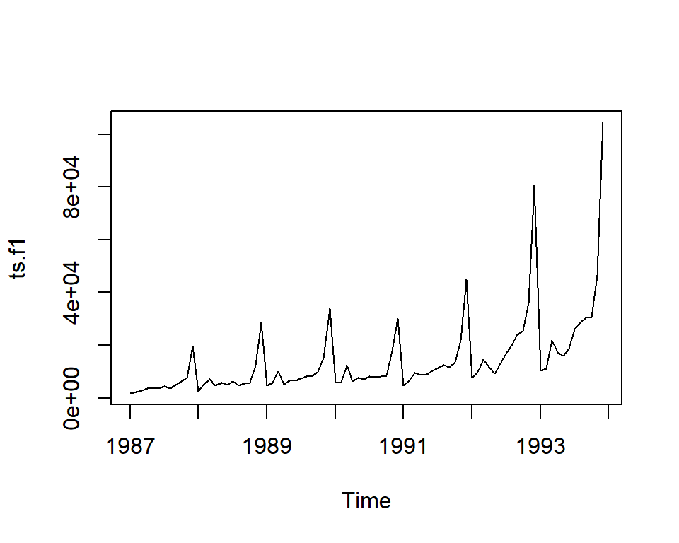

```r
plot.ts(ts.f1)
```

The size of the seasonal fluctuations and random fluctuations seem to increase with the level of the time series. In these cases it is reasonable to transform the time series by calculating the natural logarithm of the original data.

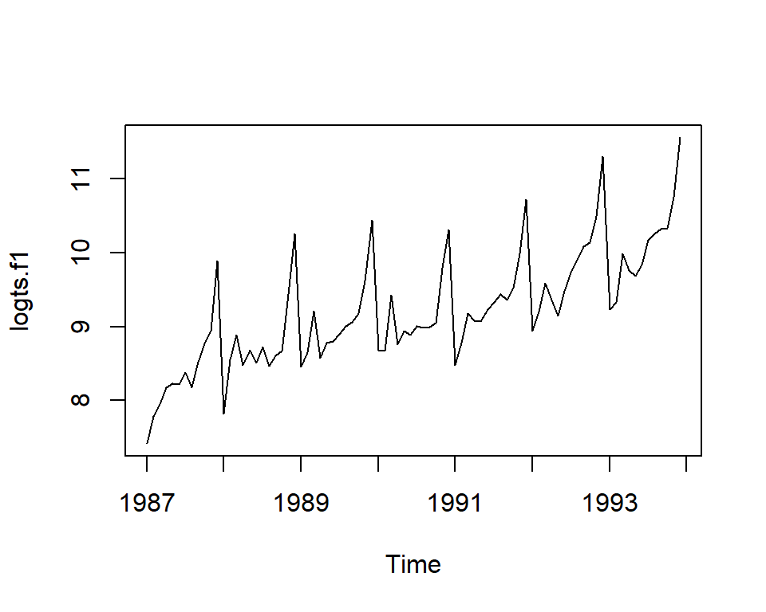

```r
logts.f1 <- log(ts.f1)
plot.ts(logts.f1)
```

See [time plots](https://otexts.org/fpp2/time-plots.html).

## 4.3 Time Series Components

A time series has usually a trend component and an irregular component and, if it turns out to be a seasonal time series, a seasonal component as well.

See [Time series patterns: Trend, Seasonal, Cyclic](https://otexts.org/fpp2/tspatterns.html).

### 4.3.1 Seasonal plot

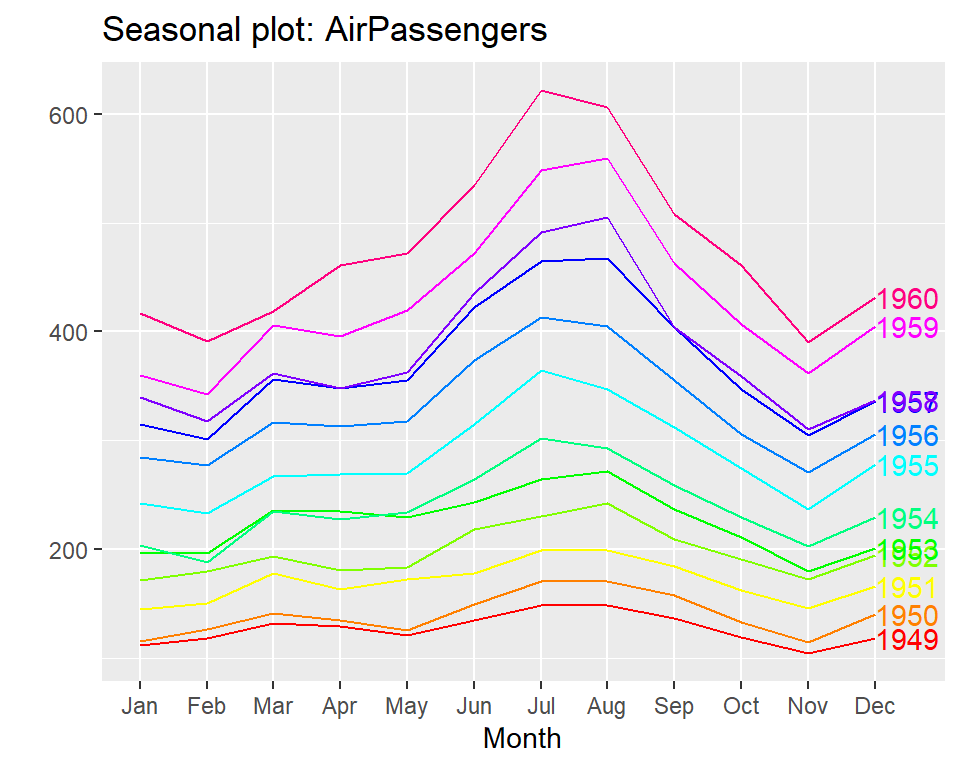

```r
# https://www.rdocumentation.org/packages/forecast/versions/8.4/topics/ggseasonplot
library("forecast")
data("AirPassengers")
ggseasonplot(AirPassengers, col = rainbow(12), year.labels = TRUE)
```

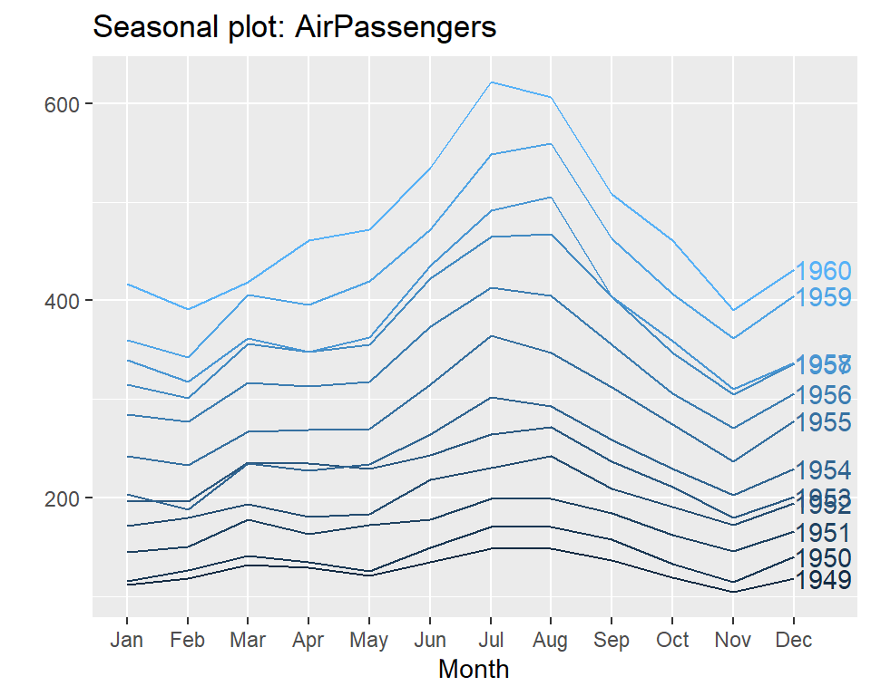

```r
ggseasonplot(AirPassengers, year.labels = TRUE, continuous = TRUE)
```

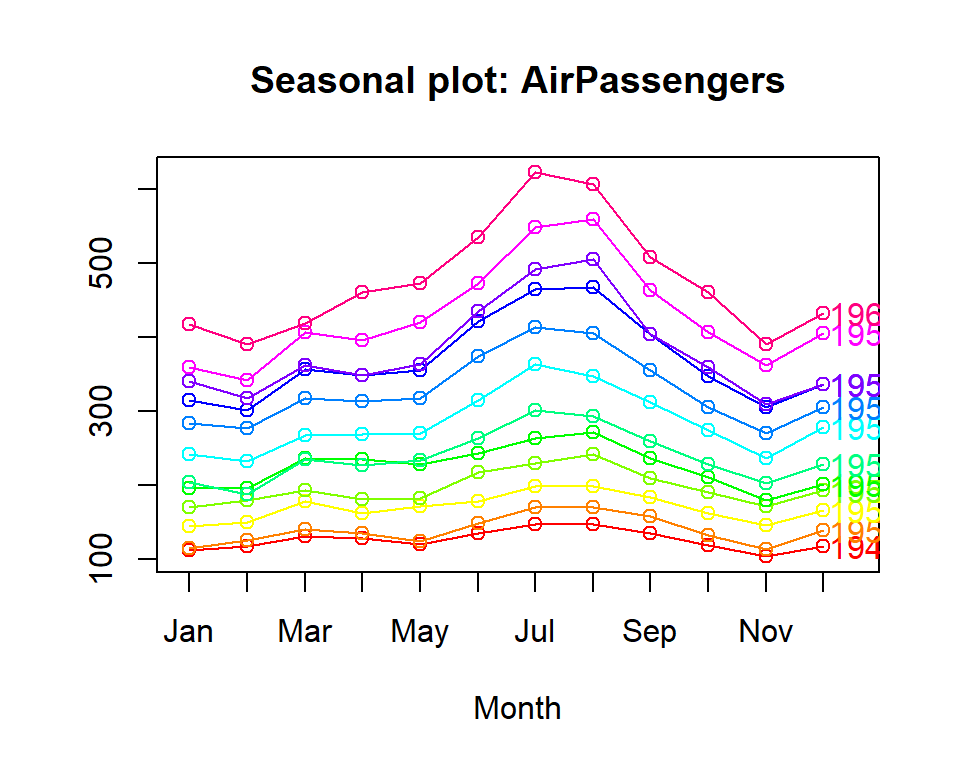

```r
seasonplot(AirPassengers, col = rainbow(12), year.labels = TRUE)
```

### 4.3.2 Subseries plot

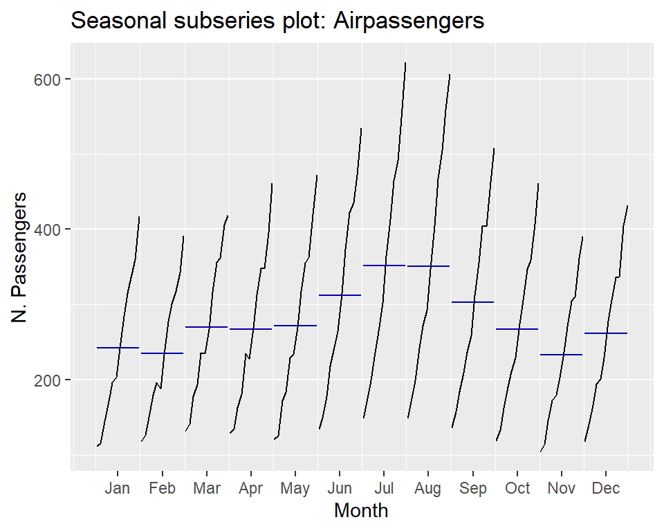

```r
library(ggplot2)
ggsubseriesplot(AirPassengers) +
  ylab("N. Passengers") +
  ggtitle("Seasonal subseries plot: Airpassengers")
```

The mean is indicated by horizontal lines.

See [Time series graphics: Scatterplots, lag plots, etc.](https://otexts.org/fpp2/graphics.html).

# 5 Other packages

- base R: times series class named ts. too restrictive, functiones associated limited
- zoo, xts packages: to represent time series
  - special structure for time series
  - many functions interestings

### **Exercise**

- Make an .rmd with a mini-tutorial on the use of the zoo and xts packages, applying them to a time series (dataset with data from Spain) that you search on the web about electricity consumption, product consumption, etc.
- Hand in the homework of the time series topic.

# 6 Basic forecasting methods

We denote $\hat{y}_{T+h\mid T}$ the value of the variable $y$ in the time $T+h$ based on $y_1, \ldots, y_T$.

The residual will be computed by:

$$e_T=y_T-\hat{y}_{T}$$
The forecast error is:
$$e_t(T)=y_t-\hat{y}_{t}(t-T)$$

## 6.1 Average method

$$\hat{y}_{T+h\mid T}=\frac{(y_1, \ldots, y_T)}{T}$$

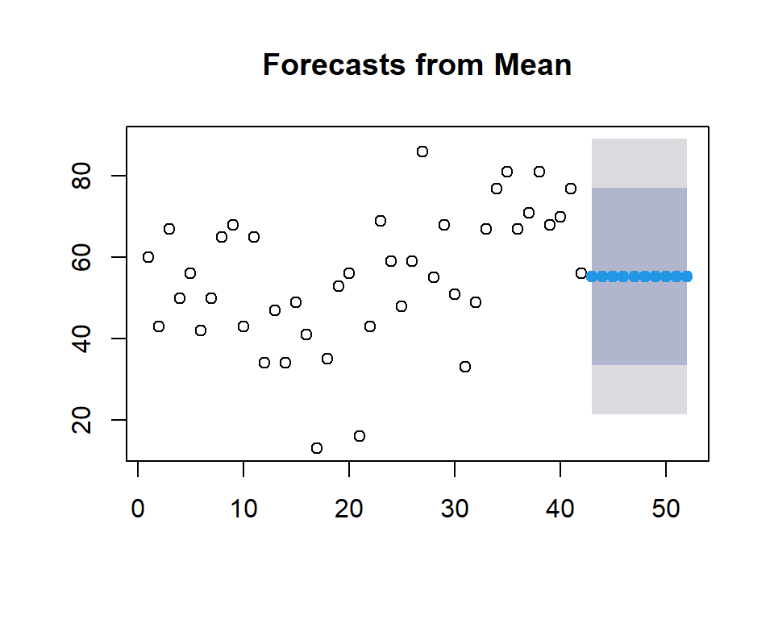

```r
data.ts.k1 <- scan("ts_k1.dat", skip = 1)
mdata.ts.k1 <- meanf(data.ts.k1, 10)
plot(mdata.ts.k1)
```

## 6.2 Naïve method

The prediction will be the last $Y_T$.

$$\hat{y}_{T+h\mid T}= y_T$$

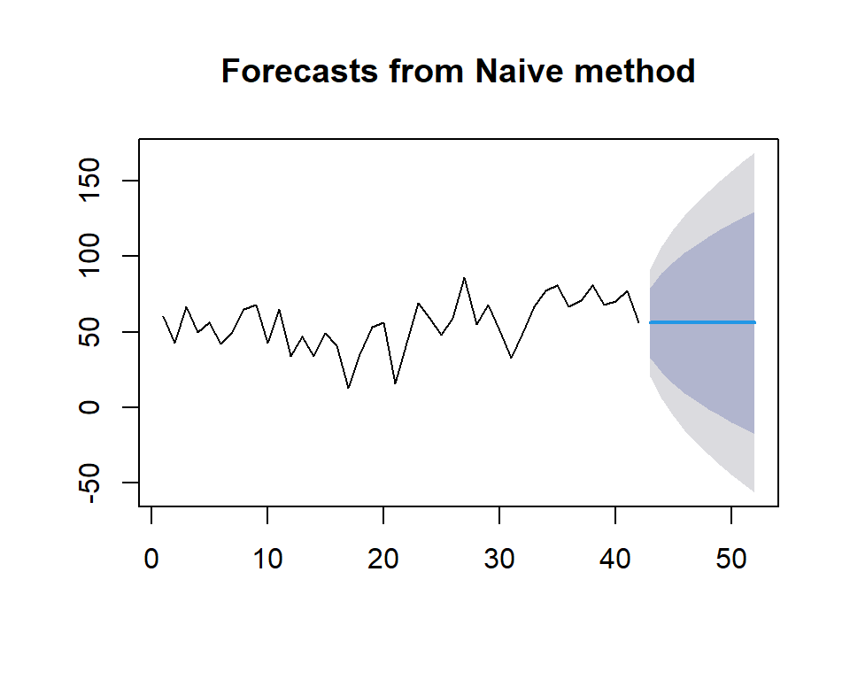

```r
data.ts.k1 <- scan("ts_k1.dat", skip = 1)
h <- 10
mdata.ts.k1 <- naive(data.ts.k1, h)
plot(mdata.ts.k1)
```

## 6.3 Seasonal naïve method

The prediction will be the same that the value of the variable in the last year in the same time.

$$\hat{y}_{T+h\mid T}= y_{T+h-m(k+1)}$$
(where $m$ is the season in the year and $k$ is the truncated value of $(h-1)/m$)

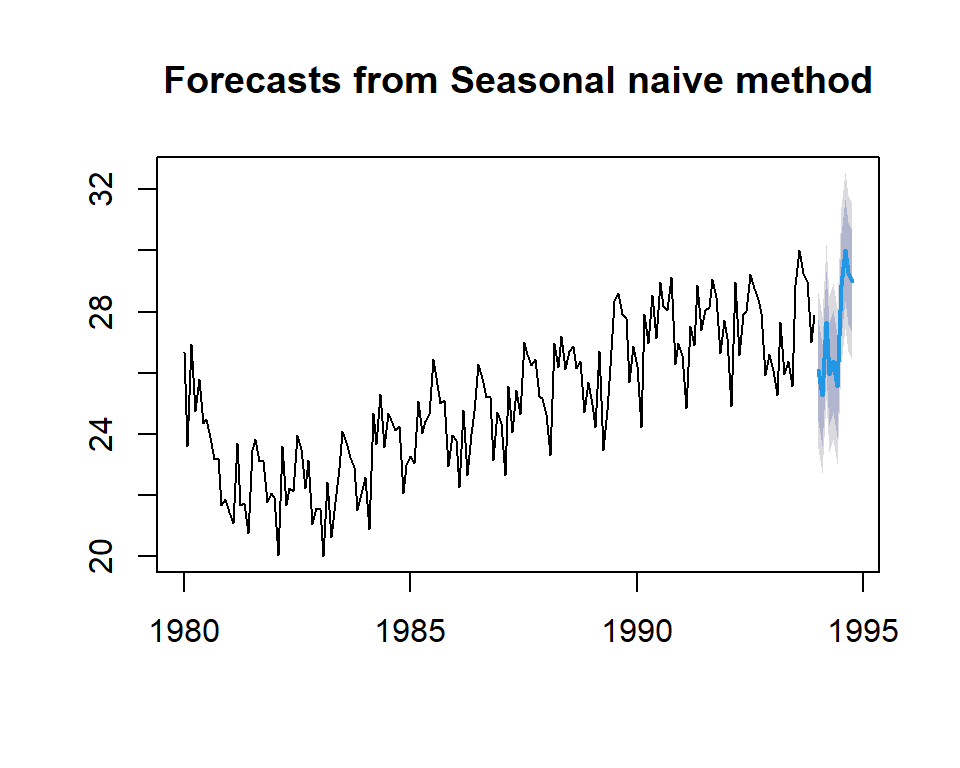

```r
tsn1 <- scan("ts_n1.dat", skip = 1)
ts.n1 <- ts(tsn1, frequency = 12, start = c(1980, 1))
h <- 10
mdata.ts.k1 <- snaive(ts.n1, h)
plot(mdata.ts.k1)
```

## 6.4 Drift method

It is based on naïve method where the amount of change in time (the drift) is set as the average change in the historical data:

$$\hat{y}_{_{T+h\mid T}}=y_{_{T}}+\frac{h}{T-1}\displaystyle\sum_{t=2}^T(y_t-t_{t-1})=y_{_{T}}+h\frac{y_{_T}-y_{_{1}}}{T-1}$$

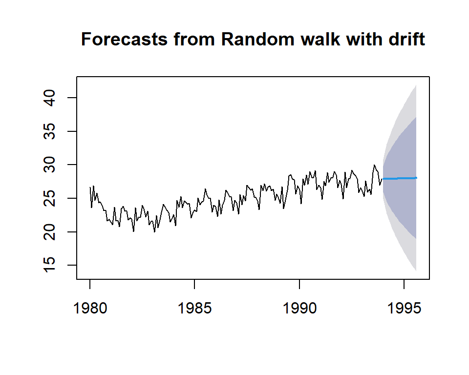

```r
h <- 20
mdata.ts.k1 <- rwf(ts.n1, h, drift = TRUE)
plot(mdata.ts.k1)
```

See all the methods in the same picture - [Forecasts for quarterly beer production](https://otexts.org/fpp2/simple-methods.html#fig:beerf).

Note: It is necessary the package **fpp2** to execute the code in this page.

# 7 Example: Temperature forecast in Malaga - Basic forecasting methods

To analyse the evolution of minimum temperatures since 2001 in Malaga.

First of all we obtain a time-series object with the function **ts**, as our data are divided into months, we set the parameter *frecuency* to 12 and we indicate that we start in January 2001. After this, we draw the object obtained:

```r
library('ggplot2')
library('TTR')
library('forecast')
library('tseries')
```

```r
library(readr)
temperaturas <- read_csv("./temp.csv")
```

```r
ts.p1 <- ts(temperaturas$tm_min, start = c(2001, 1), frequency = 12)
plot.ts(ts.p1, xlab = "años", ylab = "temperatura mínima", main = "Temperaturas mínimas Málaga")
```

[output not shown]

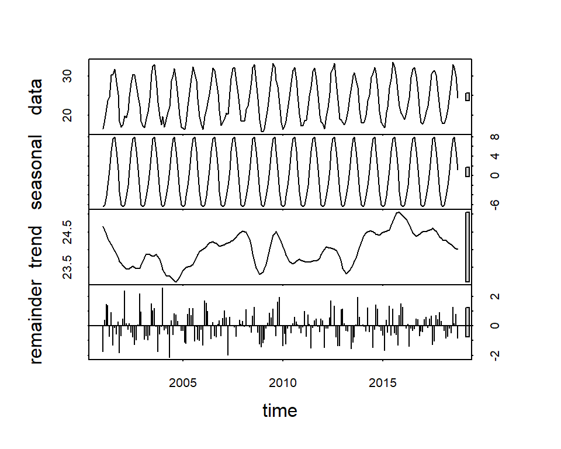

```r
# obtenemos una serie temporal con frecuencia 12 meses
obj.ts <- ts(na.omit(temperaturas$tm_max), frequency = 12, start = c(2001, 1))

# descompose
decomp <- stl(obj.ts, s.window = "periodic") # uses additive model by default
# decomposing the series and removing the seasonality can be done with seasadj() within the forecast package
deseasonal_cnt <- seasadj(decomp)
plot(decomp)
```

Let’s see if it is seasonal, let’s look at the data by year:

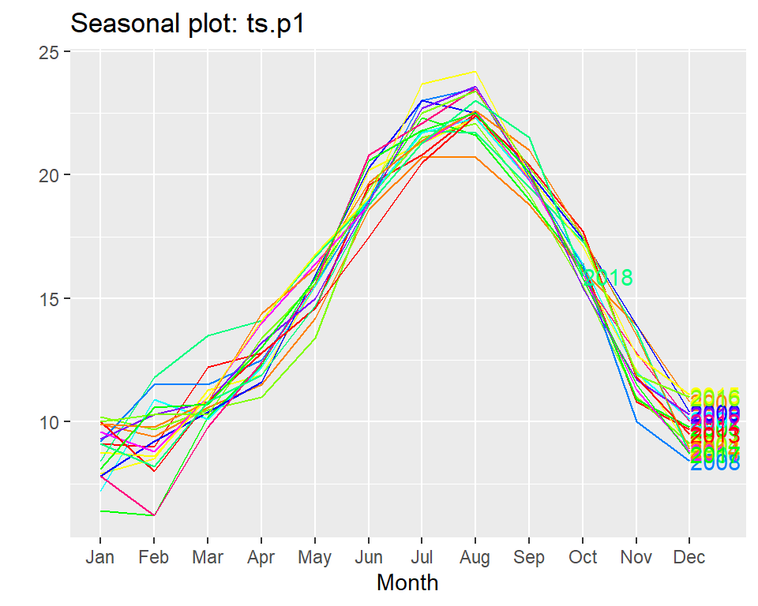

```r
ggseasonplot(ts.p1, col = rainbow(12), year.labels = TRUE)
```

With these graphs we can see that our series is seasonal, at the beginning of the year it is down, during the year it rises and from August onwards it starts to fall. This cycle is repeated every year.

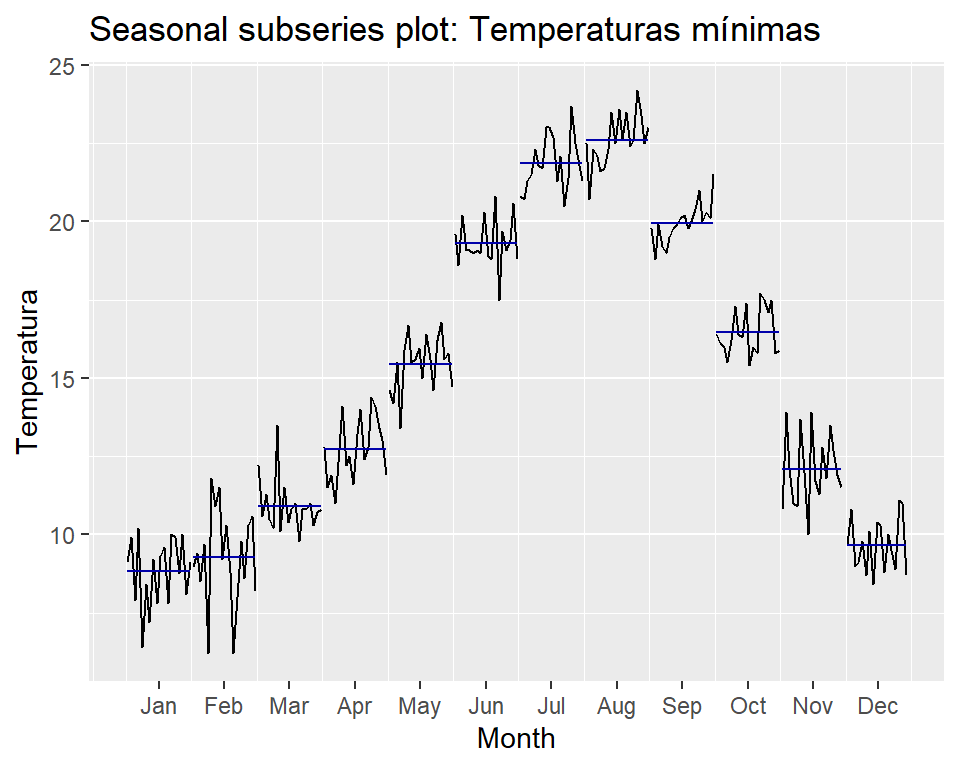

```r
ggsubseriesplot(ts.p1) +
  ylab("Temperatura") +
  ggtitle("Seasonal subseries plot: Temperaturas mínimas")
```

With this last graph we see the subseries by months. From it we see how each month moves in the same range. With this we confirm that it is a seasonal series.

### 7.0.1 Average method

With this method we see that the prediction is basically an average.

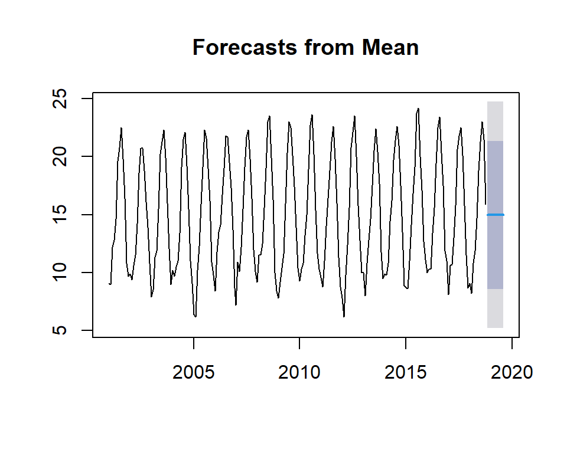

```r
mdata.ts.p1 <- meanf(ts.p1,10)
plot(mdata.ts.p1)
```

### 7.0.2 Naïve method

This method uses the last value of $y_t$.

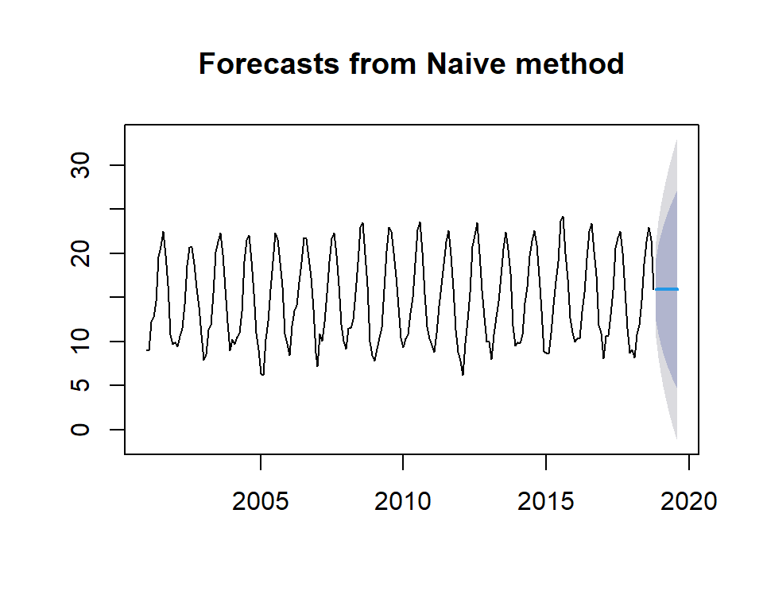

```r
mdata.ts.p1 <- naive(ts.p1, 10)
plot(mdata.ts.p1)
```

### 7.0.3 Seasonal naïve method

This method uses the last year to predict. As we will see in the graph, it generates what has happened in the last year.

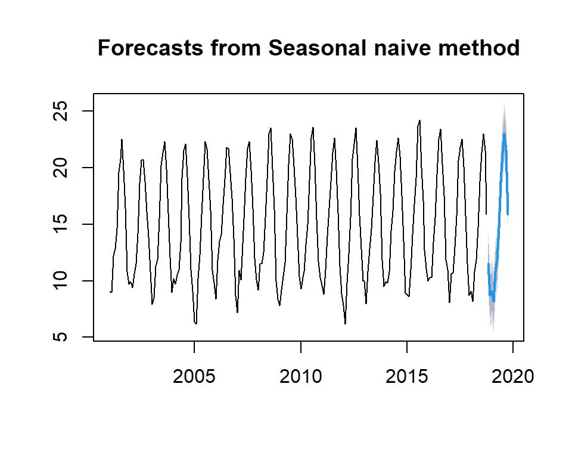

```r
mdata.ts.p1 <- snaive(ts.p1, 12)
plot(mdata.ts.p1)
```

### 7.0.4 Drift method

This method is based on the previous one and that the amount of change over time is set as the average change in the historical data.

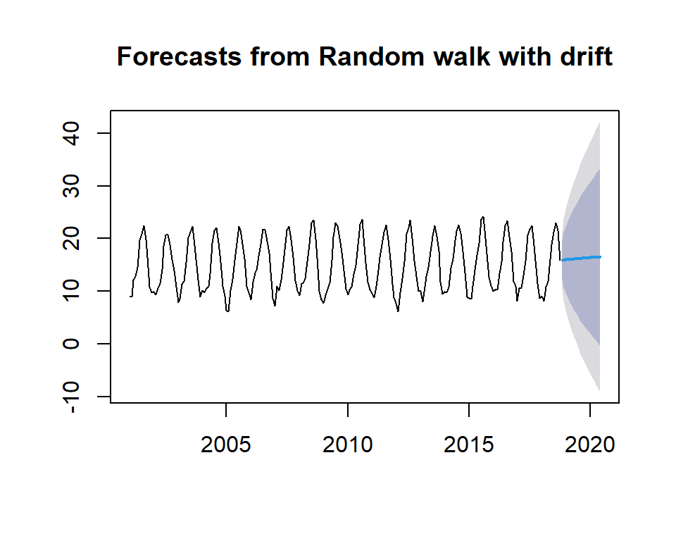

```r
mdata.ts.p1 <- rwf(ts.p1, 20, drift = TRUE)
plot(mdata.ts.p1)
```

## 7.1 Conclusion

My data series as I have mentioned is for minimum temperatures, so these methods are too simple to predict well what will happen with the temperature in the following years. The only model that could be used is the *Seasonal naïve method* which uses the last year to see what will happen next year. But we still need to use better methods.

# 8 Decomposing Time Series

Decomposing a time series means separating it into its constituent components: trend, cycles, irregular, a seasonal component and a remainder component.

If $S_t$ is the seasonal component, $T_t$ is the trend-cycle component, and $R_t$ is the remainder component, we can consider an **additive decomposition** or a **multiplicative decomposition** as follows:

Additive decomposition:
$$y_t=S_t+T_t+R_t$$
Multiplicative decomposition:
$$y_t=S_t\times T_t\times R_t$$

- Addditve decomposition is adequate when the seasonal part and the trend-cycle does not vary too much.
- Multiplicative decomposition is adequate when the amplitude of the seasonal part increases or decreases with the average level of the time series.

Multiplicative decomposition can be transformed into an additive one just by applying logarithms:
$$\log y_t= \log S_t + \log T_t +\log R_t$$

# 9 Additive decomposition

We describe how decompose a time series considering additive decomposition.

**Note:** Multiplicative decomposition is similar, except that the subtractions are replaced by divisions.

## 9.1 Non-Seasonal Data

- A non-seasonal time series consists of a trend component and an irregular component.
- To estimate the trend component of a non-seasonal time series that can be described using an *additive model*, it is common to use a smoothing method, such as calculating the Simple Moving Average (SMA) of the time series.

The **SMA()** function in the *TTR* package is used to smooth time series data using a simple moving average:

$$\hat{y_{_t}}=\frac{1}{m}\displaystyle\sum_{j=-k}^k y_{_{t+j}}$$

To compute the average eliminates randomness in the data.

To specify the order of the simple moving average, the parameter $n$ will be used. For example, to calculate a simple moving average of order 2, we set $n=2$ in the SMA() function.

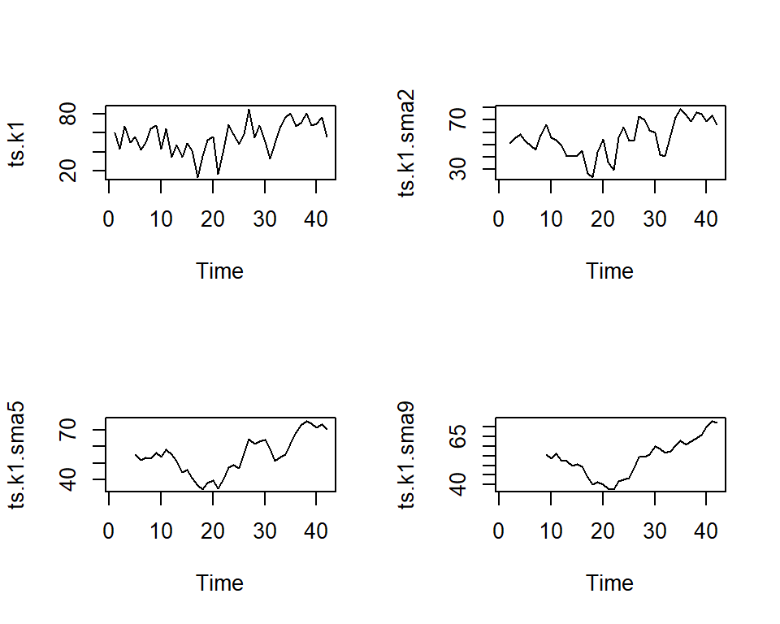

```r
library("TTR")
# simple moving average of order 2
# applied in the first dataset
data.ts.k1 <- scan("ts_k1.dat", skip = 1)
ts.k1 <- ts(data.ts.k1)

# Applying the MA of order 2,5,9
ts.k1.sma2 <- SMA(ts.k1, n = 2)
ts.k1.sma5 <- SMA(ts.k1, n = 5)
ts.k1.sma9 <- SMA(ts.k1, n = 9)

# Draw all the pictures together
par(mfrow = c(2, 2))
plot.ts(ts.k1)
plot.ts(ts.k1.sma2)
plot.ts(ts.k1.sma5)
plot.ts(ts.k1.sma9)
```

There still appears to be quite a lot of random fluctuations in the time series smoothed using a simple moving average of order 2.

Thus, to estimate the trend component more accurately, we might want to try smoothing the data with a simple moving average of a higher order. This takes a little bit of trial-and-error, to find the right amount of smoothing.

With MA of order 5, and order 9 the trend starts to be clearly identified in the plots.

## 9.2 Seasonal Data

A seasonal time series consists of a trend component, a seasonal component and an irregular component.

We can use the **decompose** function in R which estimates:

- the trend-cycle component using MA $\hat{y_t}$,
- the detrended serie $y_t-\hat{y_t}$
- the seasonal component $S_t$, computing the average of the detrended values for that season,
- the random components $R_t=y_t-\hat{y_t}-S_t$.

To compute the detrended serie in additive decomposition: $y_t-T_t =S_t+R_t$

Given the time series **ts.n1**, we will decompose the time serie using the following:

```r
tsn1 <- scan("ts_n1.dat", skip = 1)
ts.n1 <- ts(tsn1, frequency = 12, start = c(1980, 1))
ts.n1.comp <- decompose(ts.n1)
```

The estimated seasonal factors are given for the months January-December, and are the same for each year.

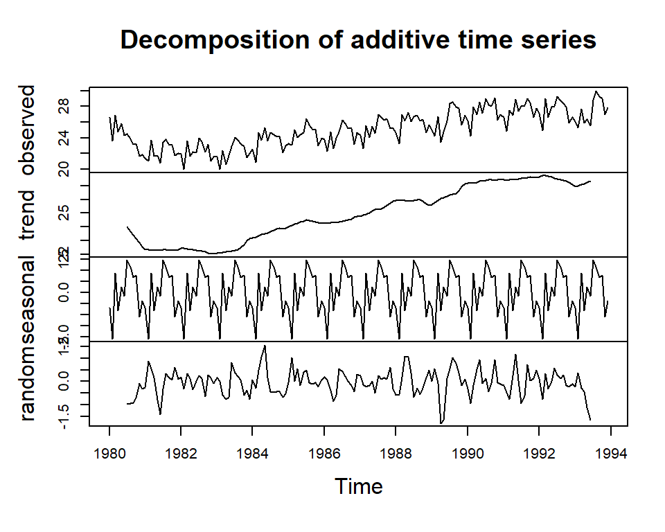

```r
plot(ts.n1.comp)
```

The different parts of the decomposed series can be managed as usual:

```r
ts.n1.comp$trend
ts.n1.comp$seasonal
ts.n1.comp$random
```

## 9.3 Seasonal Adjusting

As we have explained, if you have a seasonal time series that can be described using an *additive model*, you can seasonally adjust the time series by estimating the seasonal component, and subtracting the estimated seasonal component from the original time series.

```r
ts.n1.comp <- decompose(ts.n1)
ts.n1.comp.aj <- ts.n1 - ts.n1.comp$seasonal

ts.n1.comp.aj
```

```
##           Jan      Feb      Mar      Apr      May      Jun      Jul      Aug
## 1980 27.34019 25.68096 26.06848 25.54168 25.55435 24.51726 23.02095 22.73641
## 1981 22.11619 23.17196 22.84648 22.47068 21.50035 20.91426 22.02295 22.65941
## 1982 22.61419 22.11796 22.72748 22.47368 21.97035 22.27626 22.49395 22.33941
## 1983 22.22519 22.08296 21.56148 21.41668 21.50935 23.02726 22.64795 22.58341
## 1984 23.28119 22.97696 23.81448 24.47468 25.06835 23.73626 23.21495 23.28941
## 1985 23.96419 25.13196 24.21348 24.83868 24.17835 24.82026 24.99495 24.45341
## 1986 24.47519 24.35296 23.91248 23.44768 23.73635 24.89026 24.81995 24.65141
## 1987 25.04119 24.72696 24.70248 24.86368 25.17935 24.78826 25.55295 25.44141
## 1988 25.33419 25.38696 26.11948 27.00068 26.95835 26.27526 25.24995 25.71341
## 1989 25.66719 26.32196 25.85848 24.27668 24.51535 26.37226 26.90495 27.43441
## 1990 26.89419 26.30096 27.05148 27.77668 28.27535 27.29226 27.52595 27.00441
## 1991 27.26619 26.93096 26.68048 27.69768 28.62635 27.54326 26.60895 26.97641
## 1992 27.80919 27.00696 28.10048 27.39068 27.67935 28.16226 27.77295 27.59441
## 1993 26.75319 27.36896 26.79748 26.75268 26.14635 25.71826 27.40895 28.83541
##           Sep      Oct      Nov      Dec
## 1980 22.48338 22.45176 22.78177 22.24682
## 1981 22.41338 22.33476 22.86877 22.44982
## 1982 21.54638 22.36676 22.16877 21.94982
## 1983 22.57038 22.13176 22.62877 22.40182
## 1984 23.43038 23.47676 23.19377 23.36782
## 1985 24.32238 24.33476 24.07377 24.35782
## 1986 24.51838 24.42376 24.27177 25.08382
## 1987 25.57638 25.68676 26.35577 25.55682
## 1988 25.46038 25.60376 25.82177 26.06482
## 1989 27.22238 27.00876 26.80277 27.25782
## 1990 27.36438 28.36076 27.40077 27.36382
## 1991 28.35638 27.70876 27.74377 28.11182
## 1992 27.71338 27.16976 27.02177 26.99582
## 1993 28.56938 28.23676 28.10177 28.27382
```

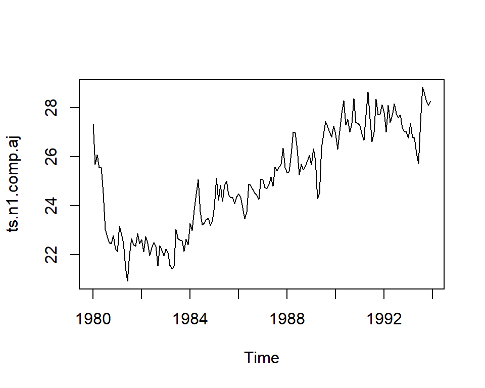

```r
plot(ts.n1.comp.aj)
```

The seasonal variation has been removed from the seasonally adjusted time series. The seasonally adjusted time series now just contains the trend component and an irregular component.

# 10 Example: Temperature forecast in Malaga - Decomposing Time Series

We have seen that the time series we use is seasonal so we are going to use the method of *Additive decomposition*.

## 10.1 Additive decomposition

A seasonal time series consists of a trend component, a seasonal component and an irregular component. To decompose it we are going to use **decompose**.

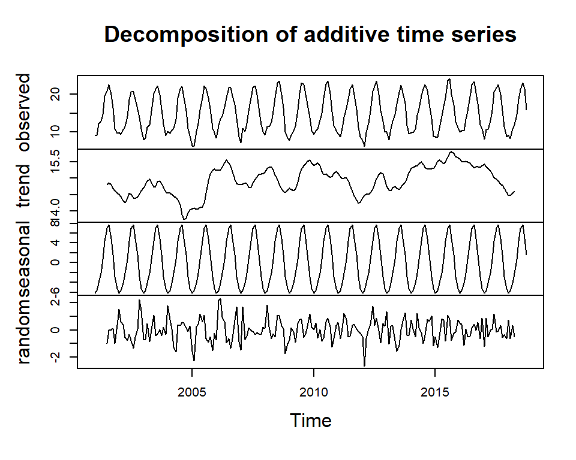

```r
# we decompose the time series and draw it
ts.p1.comp <- decompose(ts.p1)
plot(ts.p1.comp)
```

## 10.2 Seasonal Adjusting

If we have a seasonal time series that can be described using an additive model, we can seasonally adjust the time series by estimating the seasonal component and subtracting the estimated seasonal component from the original time series.

```r
# we subtract the stationary component
ts.p1.comp.aj <- ts.p1 - ts.p1.comp$seasonal
ts.p1.comp.aj
```

```
##           Jan      Feb      Mar      Apr      May      Jun      Jul      Aug
## 2001 15.21772 14.62312 16.29322 15.00204 13.99887 15.21996 13.84395 14.84199
## 2002 16.01772 15.02312 14.69322 13.70204 13.59887 14.21996 13.74395 13.04199
## 2003 14.01772 14.12312 15.39322 14.10204 14.89887 15.81996 14.34395 14.64199
## 2004 16.31772 15.32312 14.59322 13.20204 12.79887 14.71996 14.54395 14.44199
## 2005 12.51772 11.82312 14.29322 14.50204 15.29887 14.71996 15.34395 13.94199
## 2006 14.51772 17.42312 17.59322 16.30204 16.09887 14.61996 14.84395 14.04199
## 2007 13.31772 16.52312 14.19322 14.40204 14.89887 14.71996 14.74395 14.64199
## 2008 15.31772 17.12312 15.59322 14.70204 14.99887 14.61996 16.04395 15.84199
## 2009 13.91772 14.82312 14.49322 13.80204 15.34887 15.91996 16.04395 14.84199
## 2010 15.41772 15.92312 14.89322 15.40204 14.39887 14.51996 15.74395 15.94199
## 2011 15.71772 14.42312 15.09322 16.20204 15.79887 14.41996 14.34395 14.94199
## 2012 13.91772 11.82312 13.89322 14.60204 14.99887 16.41996 15.14395 15.84199
## 2013 16.11772 13.62312 14.89322 15.00204 13.99887 13.11996 13.54395 14.74199
## 2014 16.01772 15.42312 14.89322 16.60204 15.59887 15.31996 14.44395 14.94199
```

[output cut: 23 more lines]

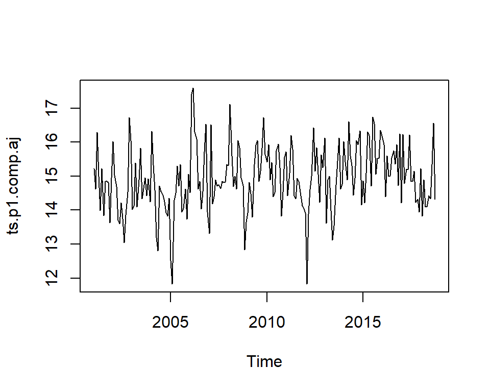

```r
# we draw the adjusted values
plot(ts.p1.comp.aj)
```

# 11 Forecasts using Exponential Smoothing

Exponential Smoothing considers weigths to the values of the variables: weighted averages of past observations. The weights decrease exponentially for distant values.

[Taxonomy](https://otexts.org/fpp2/taxonomy.html)

## 11.1 Simple Exponential Smoothing

The idea is to consider a weighted average between the value of the variable and the previous one:

$$\hat{y}_{T+1\mid T}=\alpha y_T + (1-\alpha)\hat{y}_{T\mid T-1}$$

If we have into account more past values of the variable, after some computations, the forecast will be:

$$\hat{y}_{T+1\mid T}=\alpha y_T + \alpha(1-\alpha){y}_{T-1}+\alpha(1-\alpha)^2{y}_{T-2}+\ldots$$

The parameter $\alpha$ controls the rates at which the weights decrease. The weights decrease exponentially and this is the reason of the name of the method.

- $\alpha$ has values between 0 and 1.
- $\alpha$ close to 0, more important are the longer observations - slow learning (past observations have a large influence on forecasts).
- $\alpha$ close to 1, more important the more recent observation s- fast learning (that is, only the most recent values influence the forecasts).
- With $\alpha=0$ or $\alpha=1$ we have the extreme cases.

If you have a time series that can be described using an additive model with constant level (no clear trend) and no seasonality, you can use **simple exponential smoothing** to make short-term forecasts.

- The simple exponential smoothing method provides a way of estimating the level at the current time point.

The file **ts_p1.dat** contains total annual snowfall for a city.

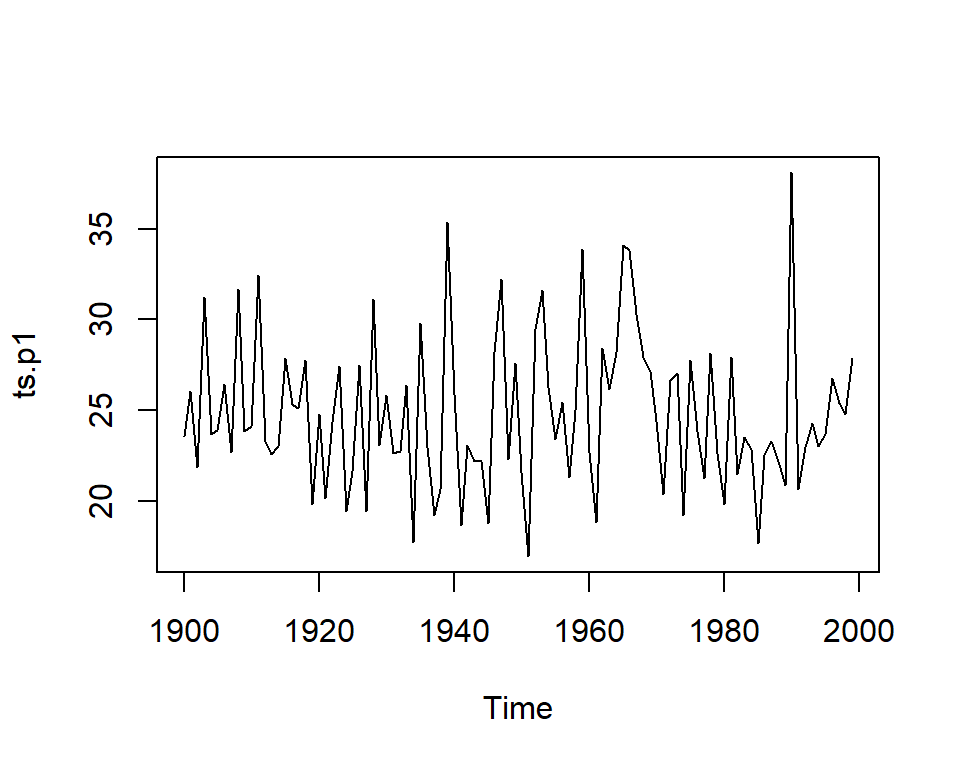

```r
tsp1 <- scan("ts_p1.dat", skip = 1)
ts.p1 <- ts(tsp1, start = c(1900))
plot.ts(ts.p1)
```

- The mean stays constant at about 25 - roughly constant level.
- The random fluctuations seem to be roughly constant.

Thus, we can make forecasts using simple exponential smoothing.

In R, we can fit a simple exponential smoothing predictive model using the **HoltWinters** function.

[Main parameters](https://docs.tibco.com/pub/enterprise-runtime-for-R/4.0.0/doc/html/Language_Reference/stats/HoltWinters.html):

- alpha: Smoothing is controlled by this parameter; the value of alpha lies between 0 and 1 (close to 0 mean that little weight is placed on the most recent observations when making forecasts of future values).
- beta=FALSE: the function will do exponential smoothing.
- gamma=FALSE: a non-seasonal model is fitted.
- seasonal: **additive by default** or multiplicative seasonal model.

```r
ts.p1.forecasts <- HoltWinters(ts.p1, beta = FALSE, gamma = FALSE)
ts.p1.forecasts
## Holt-Winters exponential smoothing without trend and without seasonal component.
##
## Call:
## HoltWinters(x = ts.p1, beta = FALSE, gamma = FALSE)
##
## Smoothing parameters:
##  alpha: 0.02412151
##  beta : FALSE
##  gamma: FALSE
##
## Coefficients:
##       [,1]
## a 24.67819
```

The output of `HoltWinters()` tells us that the estimated value of the alpha parameter is about 0.024. This is very close to zero, telling us that past observations have more influence on forecasts.

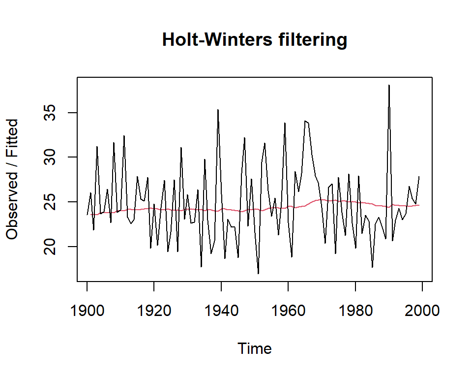

```r
plot(ts.p1.forecasts)
```

The plot shows the original time series in black, and the forecasts of these values as a red line. The time series of forecasts is much smoother than the time series of the original data here.

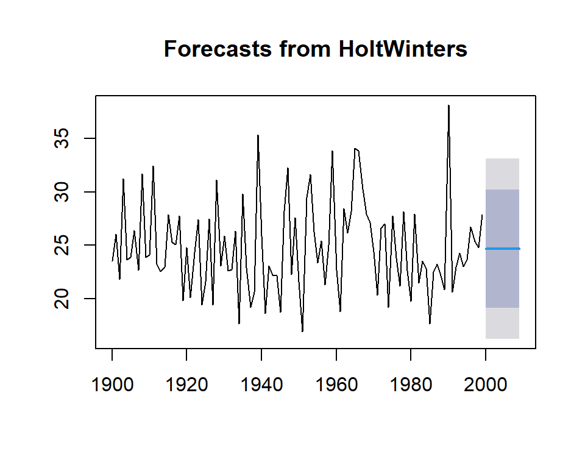

```r
plot(forecast(ts.p1.forecasts))
```

The function `forecast` predicts the value as the previous plot shows.

As a measure of the accuracy of the forecasts, we can calculate the sum of squared errors for the in-sample forecast errors, that is, the forecast errors for the time period covered by our original time series. The sum-of-squared- errors is stored in a named element of the list variable `ts.p1.forecasts` called “SSE”, so we can get its value by typing:

```r
ts.p1.forecasts$SSE
```

```
## [1] 1828.855
```

Finally, we try with different values of $\alpha$ and the errors are computed:

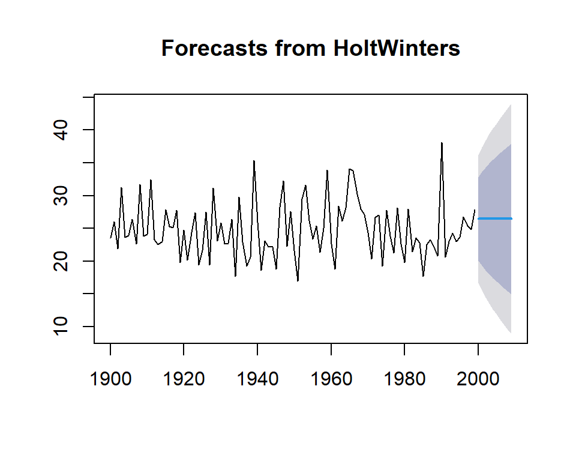

```r
ts.p2.forecasts <- HoltWinters(ts.p1, alpha = 0.5, beta = FALSE, gamma = FALSE)
ts.p2.forecasts
## Holt-Winters exponential smoothing without trend and without seasonal component.
##
## Call:
## HoltWinters(x = ts.p1, alpha = 0.5, beta = FALSE, gamma = FALSE)
##
## Smoothing parameters:
##  alpha: 0.5
##  beta : FALSE
##  gamma: FALSE
##
## Coefficients:
##       [,1]
## a 26.45644
plot(forecast(ts.p2.forecasts))
```

```r
ts.p2.forecasts$SSE
```

```
## [1] 2428.339
```

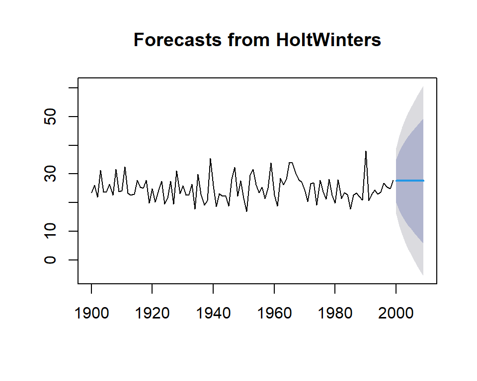

```r
ts.p3.forecasts <- HoltWinters(ts.p1, alpha = 0.9, beta = FALSE, gamma = FALSE)
ts.p3.forecasts
## Holt-Winters exponential smoothing without trend and without seasonal component.
##
## Call:
## HoltWinters(x = ts.p1, alpha = 0.9, beta = FALSE, gamma = FALSE)
##
## Smoothing parameters:
##  alpha: 0.9
##  beta : FALSE
##  gamma: FALSE
##
## Coefficients:
##       [,1]
## a 27.57778
plot(forecast(ts.p3.forecasts))
```

```r
ts.p3.forecasts$SSE
```

```
## [1] 3399.419
```

Note: The forecasts made by `HoltWinters` are stored in the list called fitted.

```r
ts.p3.forecasts$fitted
## Time Series:
## Start = 1901
## End = 1999
## Frequency = 1
##          xhat    level
## 1901 23.56000 23.56000
## 1902 25.81900 25.81900
## 1903 22.25590 22.25590
## 1904 30.34159 30.34159
## 1905 24.31916 24.31916
## 1906 23.92392 23.92392
## 1907 26.16139 26.16139
## 1908 23.01914 23.01914
## 1909 30.82291 30.82291
## 1910 24.55629 24.55629
## 1911 24.15463 24.15463
## 1912 31.60246 31.60246
## 1913 24.09425 24.09425
## 1914 22.72242 22.72242
## 1915 22.97224 22.97224
## 1916 27.38922 27.38922
## 1917 25.52692 25.52692
## 1918 25.12469 25.12469
## 1919 27.49647 27.49647
## 1920 20.58765 20.58765
## 1921 24.36076 24.36076
## 1922 20.54408 20.54408
## 1923 23.96041 23.96041
## 1924 27.07404 27.07404
## 1925 20.20340 20.20340
## 1926 21.48734 21.48734
## 1927 26.88973 26.88973
## 1928 20.17597 20.17597
## 1929 30.03460 30.03460
## 1930 23.78446 23.78446
## 1931 25.64345 25.64345
## 1932 22.94934 22.94934
## 1933 22.76993 22.76993
## 1934 26.00099 26.00099
## 1935 18.53010 18.53010
## 1936 28.68201 28.68201
## 1937 23.50520 23.50520
## 1938 19.64852 19.64852
## 1939 20.53185 20.53185
## 1940 33.85919 33.85919
## 1941 26.68692 26.68692
## 1942 19.45369 19.45369
## 1943 22.69937 22.69937
## 1944 22.25894 22.25894
## 1945 22.18789 22.18789
## 1946 19.11179 19.11179
## 1947 27.30018 27.30018
## 1948 31.74602 31.74602
## 1949 23.21760 23.21760
## 1950 27.13476 27.13476
## 1951 22.14448 22.14448
## 1952 17.45145 17.45145
## 1953 28.27714 28.27714
## 1954 31.26771 31.26771
## 1955 26.75177 26.75177
## 1956 23.73518 23.73518
## 1957 25.25152 25.25152
## 1958 21.71315 21.71315
## 1959 24.68932 24.68932
## 1960 32.94293 32.94293
## 1961 23.69729 23.69729
## 1962 19.30773 19.30773
## 1963 27.52677 27.52677
## 1964 26.29668 26.29668
## 1965 27.98267 27.98267
## 1966 33.47027 33.47027
## 1967 33.78503 33.78503
## 1968 30.63050 30.63050
## 1969 28.19105 28.19105
## 1970 27.24511 27.24511
## 1971 24.68451 24.68451
## 1972 20.78345 20.78345
## 1973 26.05435 26.05435
## 1974 26.91443 26.91443
## 1975 19.98044 19.98044
## 1976 26.96404 26.96404
## 1977 24.16140 24.16140
## 1978 21.52314 21.52314
## 1979 27.48731 27.48731
## 1980 23.09773 23.09773
## 1981 20.12977 20.12977
## 1982 27.15898 27.15898
## 1983 22.03890 22.03890
## 1984 23.37189 23.37189
## 1985 22.91119 22.91119
## 1986 18.21212 18.21212
## 1987 22.10721 22.10721
## 1988 23.16272 23.16272
## 1989 22.26927 22.26927
## 1990 20.98293 20.98293
## 1991 36.38829 36.38829
## 1992 22.22383 22.22383
## 1993 22.89538 22.89538
## 1994 24.12354 24.12354
## 1995 23.12135 23.12135
## 1996 23.61514 23.61514
## 1997 26.43651 26.43651
## 1998 25.46765 25.46765
## 1999 24.85777 24.85777
```

## 11.2 Forecasting using forecast package

We can make forecasts for further time points by using the `forecast.HoltWinters` function in the R `forecast` package.

```r
require("forecast")
library("forecast")
```

When using the `forecast.HoltWinters` function, as its first argument (input), you pass it the predictive model that you have already fitted using the `HoltWinters` function.

You specify how many further time points you want to make forecasts for by using the “h” parameter in `forecast.HoltWinters()`.

The output for the next 20 years is:

```r
# ts.p1.forecasts2 <- forecast.HoltWinters(ts.p1.forecasts, h=20)

ts.p1.forecasts2 <- forecast:::forecast.HoltWinters(ts.p1.forecasts, h = 20)
ts.p1.forecasts2
```

```
##      Point Forecast    Lo 80    Hi 80    Lo 95    Hi 95
## 2000       24.67819 19.17493 30.18145 16.26169 33.09470
## 2001       24.67819 19.17333 30.18305 16.25924 33.09715
## 2002       24.67819 19.17173 30.18465 16.25679 33.09960
## 2003       24.67819 19.17013 30.18625 16.25434 33.10204
## 2004       24.67819 19.16853 30.18785 16.25190 33.10449
## 2005       24.67819 19.16694 30.18945 16.24945 33.10694
## 2006       24.67819 19.16534 30.19105 16.24701 33.10938
## 2007       24.67819 19.16374 30.19265 16.24456 33.11182
## 2008       24.67819 19.16214 30.19425 16.24212 33.11427
## 2009       24.67819 19.16054 30.19584 16.23968 33.11671
## 2010       24.67819 19.15895 30.19744 16.23724 33.11915
## 2011       24.67819 19.15735 30.19904 16.23479 33.12159
## 2012       24.67819 19.15576 30.20063 16.23235 33.12403
## 2013       24.67819 19.15416 30.20223 16.22991 33.12647
## 2014       24.67819 19.15257 30.20382 16.22748 33.12891
## 2015       24.67819 19.15097 30.20542 16.22504 33.13135
## 2016       24.67819 19.14938 30.20701 16.22260 33.13379
## 2017       24.67819 19.14778 30.20860 16.22016 33.13623
## 2018       24.67819 19.14619 30.21020 16.21773 33.13866
## 2019       24.67819 19.14460 30.21179 16.21529 33.14110
```

The forecast for a year, a 80% prediction interval for the forecast, and a 95% prediction interval for the forecast.

Plotting the predictions:

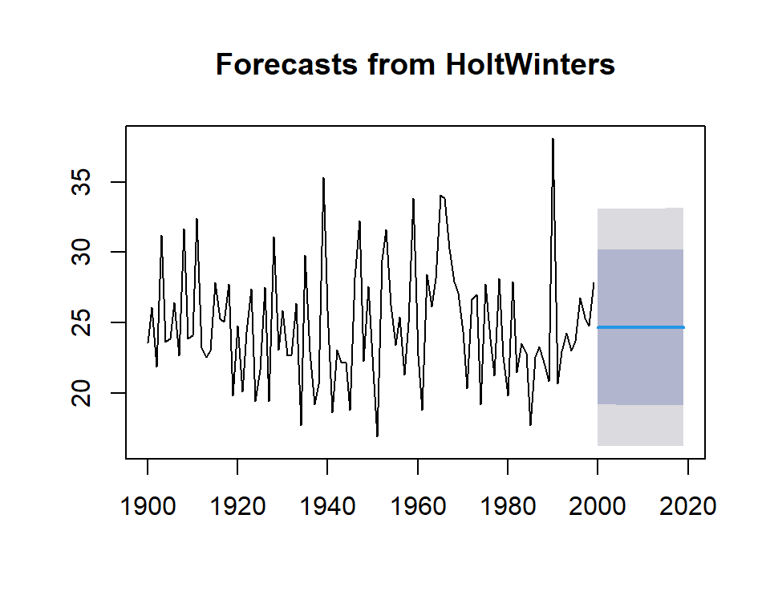

```r
forecast:::plot.forecast(ts.p1.forecasts2)
```

The forecasts for 2000-2020 are plotted as a blue line, the 80% prediction interval as a dark blue shaded area, and the 95% prediction interval as a grey shaded area.

**Forecast errors**

Forecast errors are stored in the element *residuals*.

- If the predictive model cannot be improved upon, there should be no correlations between forecast errors for successive predictions.
- If there are correlations between forecast errors for successive predictions, it is likely that the simple exponential smoothing forecasts could be improved upon by another forecasting technique.

To figure out whether this is the case, we can obtain a correlogram of the in-sample forecast errors. We can calculate a correlogram of the forecast errors using the `acf` function in R.

`acf` computes (and plots, by default) the estimation of the autocovariance or AutoCorrelation Function (ACF).

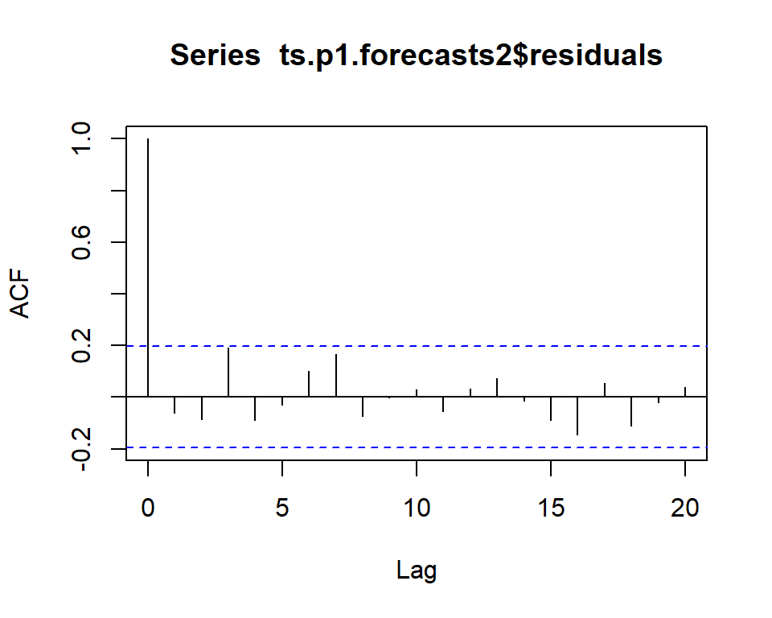

```r
acf(ts.p1.forecasts2$residuals,na.action = na.pass, lag.max = 20)
```

The autocorrelation at lag 3 is just touching the significance bounds (significant evidence for non-zero correlations).

To test whether there is significant evidence for non-zero correlations at lags, we can carry out a Ljung- Box test. This can be done in R using the **Box.test** function.

```r
Box.test(ts.p1.forecasts2$residuals, lag = 20, type = "Ljung-Box")
```

```
##
##  Box-Ljung test
##
## data:  ts.p1.forecasts2$residuals
## X-squared = 17.401, df = 20, p-value = 0.6268
```

The p-value is 0.6, so there is little evidence of non-zero autocorrelations in the in-sample forecast errors at lags 1-20.